# Complete Work

Ross Cooper 54907605

2024-07-10

# Loading Packages

```
## This version of gbm is no longer under development. Consider transitioning to gbm3, https://github.com/gbm-developers/gbm3
```

# Data Cleaning and Processing

## Student grades data cleaning

The first thing we do is read in the student grades from the csv given. After that we trim the whitespace for all character columns to ensure there are no irregularities. A course code column is created to put a course with it’s course number in the form COURSE.NUMBER.

The student grades data has not fundamentally changed.

| STUD_NO_ANONYMOUS | CURR_YEAR_LEVEL | CURR_SPEC_PRIM_PGM_TYPE_1 | CURR_SPEC_PRIM_SUBJECT_1 | HDR_CRS_PCT_GRD | COURSE_CODE | YEAR_CODE |
| --- | --- | --- | --- | --- | --- | --- |
| 5DD702CBED2E53543D16447E2475E866 | 3 | MAJ | ECON | 73 | ECON.355 | 2018S |
| 5DD702CBED2E53543D16447E2475E866 | 3 | MAJ | ECON | 84 | HIST.397 | 2018S |
| 5DD702CBED2E53543D16447E2475E866 | 4 | MAJ | ECON | 66 | ECON.327 | 2018W |
| 5DD702CBED2E53543D16447E2475E866 | 4 | MAJ | ECON | 60 | ECON.328 | 2018W |
| 5DD702CBED2E53543D16447E2475E866 | 4 | MAJ | ECON | 62 | ECON.386 | 2018W |

```
## [1] 1552
```

This chunk was used to determine the maximum number of times each course was taken. With the number of times a course was taken, we can make enough columns for each students’ retaken course grade without issue.

Here we create those columns header names to be able to create a empty data frame to fill.

### Extracting student majors and minors

This chunk is used to find each students’ major(s), minor, and whether they are taking honors. They are saved in a data frame with each student on a new row. This data frame is later fed into the studentgrades data frame including all student grades. This chunk will be run for any of the three types of students grade structure used.

### Extracting gender, citizenship, and residency

# Data Structure

## Using all student grades from retaken courses

This variation of studentgrades has each student represented as rows, and courses as columns. Course grades are recorded for each attempt a student takes at each course. Each new attempt is saved in a new column with all 3rd time attemps of MATH.101 being saved in MATH.101.3. For example, MATH 101 has 3 columns: MATH.101.1, MATH.101.2, MATH.101.3. One for each new attempt at MATH 101.

Here we create an empty data frame, add in the unique student ids and their matching majors and minors. After we loop through df_bsc_relevant_courses to add in grades to their respective student and course column.

#### Loading studentgrades_rep

| Student_ID | Major.1 | Major.2 | Minor | Honors | ECON.101.1 | ECON.101.2 | ECON.101.3 | ECON.102.1 | ECON.102.2 | ECON.102.3 |
| --- | --- | --- | --- | --- | --- | --- | --- | --- | --- | --- |
| 000A9C28CE68BB35B3AB998F54E36069 | NA | NA | NA | FALSE | NA | NA | NA | NA | NA | NA |
| 000D7939BE85535C003A41802D19B0C7 | PSYC | NA | NA | FALSE | NA | NA | NA | NA | NA | NA |
| 00128066CAB61DA3769089FA2E342DBC | NA | NA | NA | FALSE | 50 | NA | NA | 58 | NA | NA |
| 0013CBA29E4FB1FC58289E33784E8A60 | COSC | NA | PSYC | FALSE | 76 | NA | NA | 81 | NA | NA |
| 00145EE0B1F088A2E5FA612989E4E43E | PHIL | NA | NA | FALSE | 71 | NA | NA | 81 | NA | NA |

## Using only the most recent course grades

This variation of studentgrades has each student represented as rows, and courses as columns. Only the most recent attempt at each course is recorded. For example, MATH 101 has only one column: MATH.101.

To do that we only create one column per course and save the most recent grade into correct student row and course column. This will overwrite existing grades if a student has retaken a course.

#### Loading studentgrades_new

| Student_ID | Major.1 | Major.2 | Minor | Honors | Gender | Citizenship | Residency | PSYO.111 | ENGL.112 |
| --- | --- | --- | --- | --- | --- | --- | --- | --- | --- |
| 000A9C28CE68BB35B3AB998F54E36069 | NA | NA | NA | FALSE | NA | NA | NA | 57 | NA |
| 000D7939BE85535C003A41802D19B0C7 | PSYC | NA | NA | FALSE | NA | NA | NA | NA | NA |
| 00128066CAB61DA3769089FA2E342DBC | NA | NA | NA | FALSE | NA | NA | NA | NA | NA |
| 0013CBA29E4FB1FC58289E33784E8A60 | COSC | NA | PSYC | FALSE | NA | NA | NA | 72 | 54 |
| 00145EE0B1F088A2E5FA612989E4E43E | PHIL | NA | NA | FALSE | NA | NA | NA | 84 | 86 |

#### Loading studentgrades

| Student_ID | Major.1 | Major.2 | Minor | Honors | PSYO.111 | ENGL.112 | MATH.100 | MATH.101 | PSYO.121 |
| --- | --- | --- | --- | --- | --- | --- | --- | --- | --- |
| 000A9C28CE68BB35B3AB998F54E36069 | NA | NA | NA | FALSE | 57 | NA | NA | NA | 50 |
| 000D7939BE85535C003A41802D19B0C7 | PSYC | NA | NA | FALSE | NA | NA | 67 | 81 | NA |
| 00128066CAB61DA3769089FA2E342DBC | NA | NA | NA | FALSE | NA | NA | NA | NA | NA |
| 0013CBA29E4FB1FC58289E33784E8A60 | COSC | NA | PSYC | FALSE | 72 | 54 | 65 | 84 | 89 |
| 00145EE0B1F088A2E5FA612989E4E43E | PHIL | NA | NA | FALSE | 84 | 86 | NA | NA | NA |

## Using Professor data

### Cleaning process

Since all professors for each course are saved in individual csvs by subject and term we need to compile all professor data into one data frame. We save the resulting into a rdata file.

However, this data is messy and has several names in the professor column. My assumption is that TAs and co professors are added to the list along with the main professor. This chunk is used in the cleaning process and finds out how many times each unique professor name appears in the data frame.

We need to reduce the number of names in each column to only a single name in order to standardize and factor professors. While rudimentary, the one name we take is the name which has appeared the most times in the entire data frame. The logic behind this is that the names with the most occurrences over the years will be professors as opposed to students who TA for 2 years. We don’t count only names which are by themselves (no TAs etc.) to find professors with for one reason. Many subjects only list professors with their TAs resulting in many professors being excluded from the table which counts name occurrences. This messes with the professor of many courses as no professor is found in the name occurrences table.

Yes there are better solutions, however as a test to see if professor data would improve the model, this is the algorithm I chose. We could change this to save multiple professors if both appear on their own. One problem I foresee with this is when the main prof never appears on their own, but the co prof does resulting in only the co professor being saved.

The data frame rel_course_profs contains rows containing the Professor, Year, Course name, and Section for each course and section from 2018S to 2023S.

### Professor-student data structure

This was a temporary chunk used to create a data frame to test the model with. courses was saved to a short list of 8 courses which was used to initially test with GBMs

This chunk is used to make a new studentgrades_prof data frame with both courses and their respective professors as columns. By looping through each row in df_bsc_relevant_columns, the relevant data is added to studentgrades_prof.

The data frame studentgrades_prof is similar to studentgrades (most recent grades version) in that students grades are saved as rows, and each columns is a different course. Additionally, there are columns which contain the professors who taught each course there is a grade for. For example, Student X has a grade in the MATH.101 column and will therefore have a professor in the MATH.101.P column. Student Y who has not taken MATH 101 will not have a grade in MATH.101, nor a professor in MATH.101.P.

#### Loading studentgrades_prof_new

| Student_ID | Major.1 | Major.2 | Minor | Honors | Gender | Citizenship | Residency | PSYO.111 | ENGL.112 | MATH.100 | MATH.101 |
| --- | --- | --- | --- | --- | --- | --- | --- | --- | --- | --- | --- |
| 000A9C28CE68BB35B3AB998F54E36069 | NA | NA | NA | FALSE | NA | NA | NA | 57 | NA | NA | NA |
| 000D7939BE85535C003A41802D19B0C7 | PSYC | NA | NA | FALSE | NA | NA | NA | NA | NA | 67 | 81 |
| 00128066CAB61DA3769089FA2E342DBC | NA | NA | NA | FALSE | NA | NA | NA | NA | NA | NA | NA |
| 0013CBA29E4FB1FC58289E33784E8A60 | COSC | NA | PSYC | FALSE | NA | NA | NA | 72 | 54 | 65 | 84 |
| 00145EE0B1F088A2E5FA612989E4E43E | PHIL | NA | NA | FALSE | NA | NA | NA | 84 | 86 | NA | NA |

#### Loading studentgrades_prof

This is the original student grades with professor data. And what I will be using for the most part unless specified.

| Student_ID | Major.1 | Major.2 | Minor | Honors | PSYO.111 | ENGL.112 | BIOL.312.P | COSC.211.P | PHYS.121.P |
| --- | --- | --- | --- | --- | --- | --- | --- | --- | --- |
| 000A9C28CE68BB35B3AB998F54E36069 | NA | NA | NA | FALSE | 57 | NA | NA | NA | NA |
| 000D7939BE85535C003A41802D19B0C7 | PSYC | NA | NA | FALSE | NA | NA | NA | NA | NA |
| 00128066CAB61DA3769089FA2E342DBC | NA | NA | NA | FALSE | NA | NA | NA | NA | NA |
| 0013CBA29E4FB1FC58289E33784E8A60 | COSC | NA | PSYC | FALSE | 72 | 54 | NA | NA | Andrew Ogilvy |
| 00145EE0B1F088A2E5FA612989E4E43E | PHIL | NA | NA | FALSE | 84 | 86 | NA | NA | NA |

#### Loading Professor Course List

Table of courses and the professors which taught them.

|  | Professor | year_code | course_name | Section |
| --- | --- | --- | --- | --- |
| 1 | Eva Marie Kovacs-Kowalke | 2018S | ANTH.100 | 001 |
| 3 | Hugo De Burgos | 2018S | ANTH.320 | 101 |
| 5 | Ali Maleki Gargari | 2018S | APSC.178 | 001 |
| 7 | Yu Yan | 2018S | APSC.180 | 001 |
| 9 | John Alan Brereton | 2018S | APSC.181 | 001 |
| 11 | Laura Patterson | 2018S | APSC.201 | 001 |
| 13 | Yu Yan | 2018S | APSC.252 | 001 |
| 15 | Brendan D’Souza | 2018S | BIOL.116 | 001 |
| 17 | Keith Jackson | 2018S | BIOL.125 | 101 |
| 19 | Matthew Nelson | 2018S | BIOL.200 | 001 |

### Adding professors to the original dataset

# Analysis and Prediction

Throughout my time on this project I have switched which data frame I used to train and test each model and method. The three data frames are described above but are called studentgrades_rep, studentgrades, and studentgrades_prof respectively. For some of the main methods using ‘old’ data frames I will use other data frames for comparison.

Here I set up a data frame to save all model rmses

## Initial EDA

These are the first plots I made in order to get a feel for the data. They do not show much insight into the data.

```
##
## Call:
## lm(formula = maths$MATH.100.1 ~ maths$MATH.100.2)
##
## Residuals:
##     Min      1Q  Median      3Q     Max
## -33.687  -8.516   0.531   8.687  65.406
##
## Coefficients:
##                  Estimate Std. Error t value Pr(>|t|)
## (Intercept)      31.22032    2.38502  13.090   <2e-16 ***
## maths$MATH.100.2  0.03123    0.04009   0.779    0.437
## ---
## Signif. codes:  0 '***' 0.001 '**' 0.01 '*' 0.05 '.' 0.1 ' ' 1
##
## Residual standard error: 14.66 on 333 degrees of freedom
## Multiple R-squared:  0.001819,   Adjusted R-squared:  -0.001179
## F-statistic: 0.6067 on 1 and 333 DF,  p-value: 0.4366
```

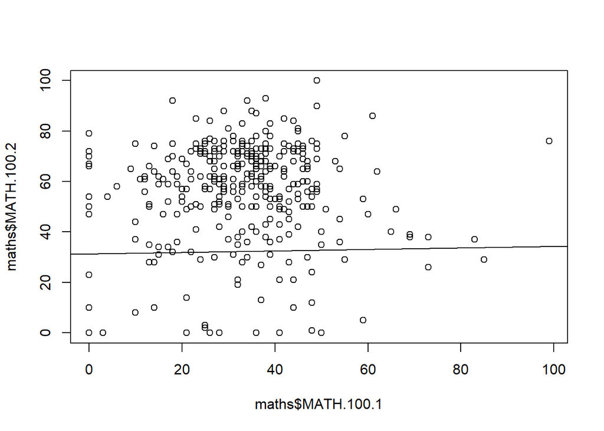

```
##
## Call:
## lm(formula = mathstat$MATH.100.1 ~ mathstat$STAT.230.1)
##
## Residuals:
##     Min      1Q  Median      3Q     Max
## -75.359  -7.432   3.309   9.899  35.916
##
## Coefficients:
##                     Estimate Std. Error t value Pr(>|t|)
## (Intercept)         40.66774    2.99633   13.57   <2e-16 ***
## mathstat$STAT.230.1  0.53372    0.04073   13.11   <2e-16 ***
## ---
## Signif. codes:  0 '***' 0.001 '**' 0.01 '*' 0.05 '.' 0.1 ' ' 1
##
## Residual standard error: 15.11 on 611 degrees of freedom
## Multiple R-squared:  0.2194, Adjusted R-squared:  0.2181
## F-statistic: 171.7 on 1 and 611 DF,  p-value: < 2.2e-16
```

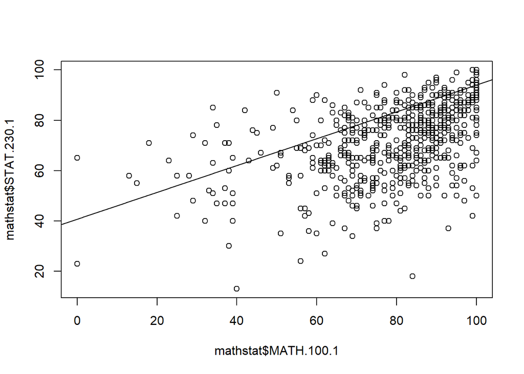

```
##
## Call:
## lm(formula = mathstat2$MATH.100.2 ~ mathstat2$STAT.230.1)
##
## Residuals:
##     Min      1Q  Median      3Q     Max
## -34.575  -6.526   1.693   8.413  24.572
##
## Coefficients:
##                      Estimate Std. Error t value Pr(>|t|)
## (Intercept)           50.1135     9.3152   5.380 7.97e-06 ***
## mathstat2$STAT.230.1   0.2439     0.1577   1.546    0.133
## ---
## Signif. codes:  0 '***' 0.001 '**' 0.01 '*' 0.05 '.' 0.1 ' ' 1
##
## Residual standard error: 14.77 on 30 degrees of freedom
## Multiple R-squared:  0.07379,    Adjusted R-squared:  0.04292
## F-statistic:  2.39 on 1 and 30 DF,  p-value: 0.1326
```

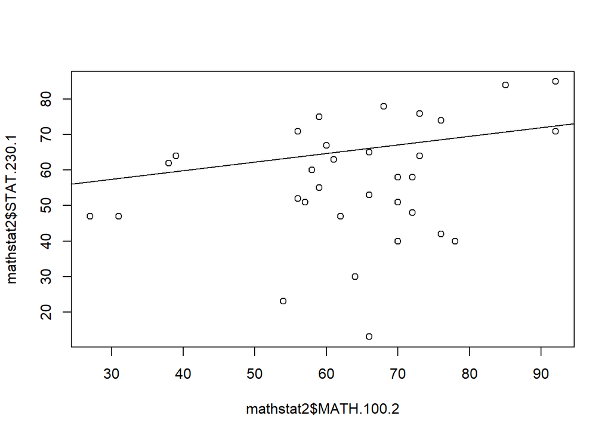

```
##
## Call:
## lm(formula = firsttimer$MATH.100.1 ~ firsttimer$STAT.230.1)
##
## Residuals:
##     Min      1Q  Median      3Q     Max
## -78.393  -7.291   2.305   8.873  29.891
##
## Coefficients:
##                       Estimate Std. Error t value Pr(>|t|)
## (Intercept)           52.15615    2.62710   19.85   <2e-16 ***
## firsttimer$STAT.230.1  0.40364    0.03536   11.41   <2e-16 ***
## ---
## Signif. codes:  0 '***' 0.001 '**' 0.01 '*' 0.05 '.' 0.1 ' ' 1
##
## Residual standard error: 12.3 on 579 degrees of freedom
## Multiple R-squared:  0.1837, Adjusted R-squared:  0.1823
## F-statistic: 130.3 on 1 and 579 DF,  p-value: < 2.2e-16
```

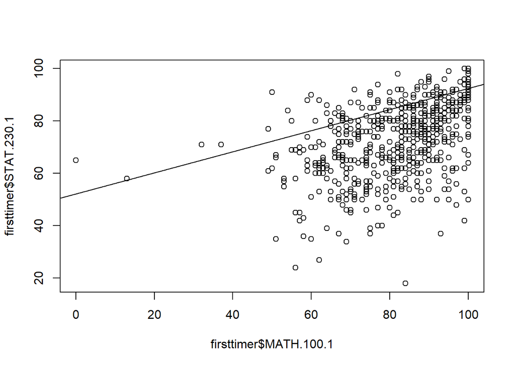

This chunk uses studentgrades_rep and makes a data frame including each course and its average grade.

This chunk uses studentgrades_rep to make a pairplot of MATH.100.1, MATH.101.1, STAT.230.1, DATA.101.1.

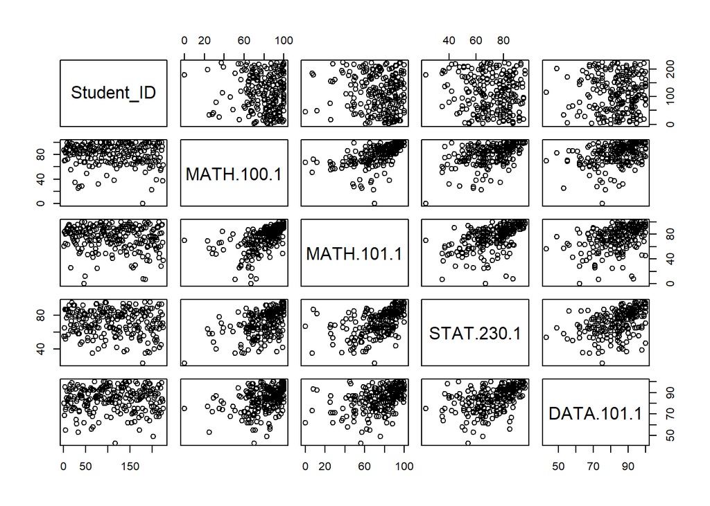

This is the same pairplot as above using only students who have taken STAT 230.

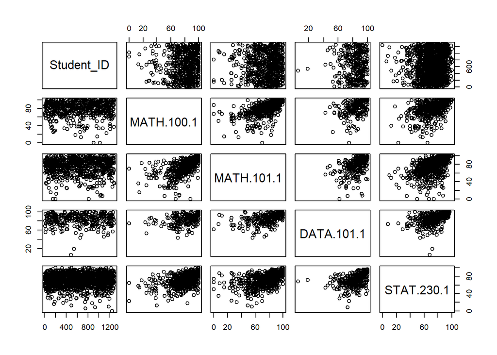

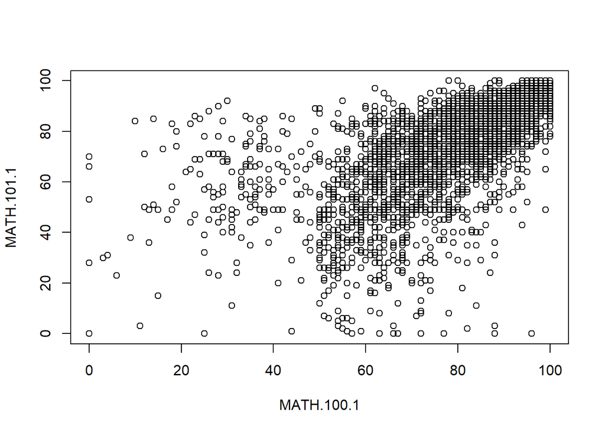

This chunk returns the number of times a course has been taken by students WHO HAVE ALL TAKEN stat 230. Used to view variables which may be useful. This code is used in a later chunk.

This is an oversimplified linear regression on STAT.230 using pre requisite courses. Oversimplified meaning we take COSC.221 and MATH.101 as the pre reqs when in reality they are: One of MATH 101, MATH 103, MATH 142 and one of DATA 101, COSC 221.

```
##
## Call:
## lm(formula = STAT.230 ~ COSC.221 + MATH.101, data = rel_grades[train_indices,
##     ])
##
## Residuals:
##     Min      1Q  Median      3Q     Max
## -42.145  -6.172   1.082   6.992  32.895
##
## Coefficients:
##             Estimate Std. Error t value Pr(>|t|)
## (Intercept) 11.52330    3.76087   3.064  0.00233 **
## COSC.221     0.51999    0.04792  10.851  < 2e-16 ***
## MATH.101     0.28889    0.04732   6.105 2.42e-09 ***
## ---
## Signif. codes:  0 '***' 0.001 '**' 0.01 '*' 0.05 '.' 0.1 ' ' 1
##
## Residual standard error: 10.79 on 403 degrees of freedom
## Multiple R-squared:  0.419,  Adjusted R-squared:  0.4161
## F-statistic: 145.3 on 2 and 403 DF,  p-value: < 2.2e-16
```

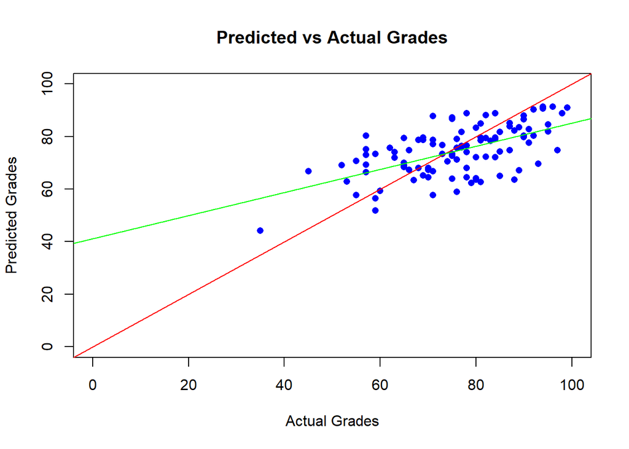

## First Prediction Attempts

These first attempts were made on either studentgrades_rep or studentgrades. Attempts made using studentgrades_prof were added in after for comparison.

### MissForest

The MissForest package is used to impute missing data. After using it to impute NA’s into student grades, we can use the imputed data set with other models which don’t allow for missing data/NAs. One of this packages use cases was imputing the data and using it in a Random Forest model. Since imputation is computationally expensive, we only impute on a small number of courses. Unfortunately, due to the way in which I implemented this model into others there was some leaked information resulting in misleading rmse values. This chunk uses studentgrades_rep and only uses each selected courses first attempt to impute and predict.

In this chunk I cut right to the chase and use the imputed values as grade predictions. As expected it doesn’t work very well.

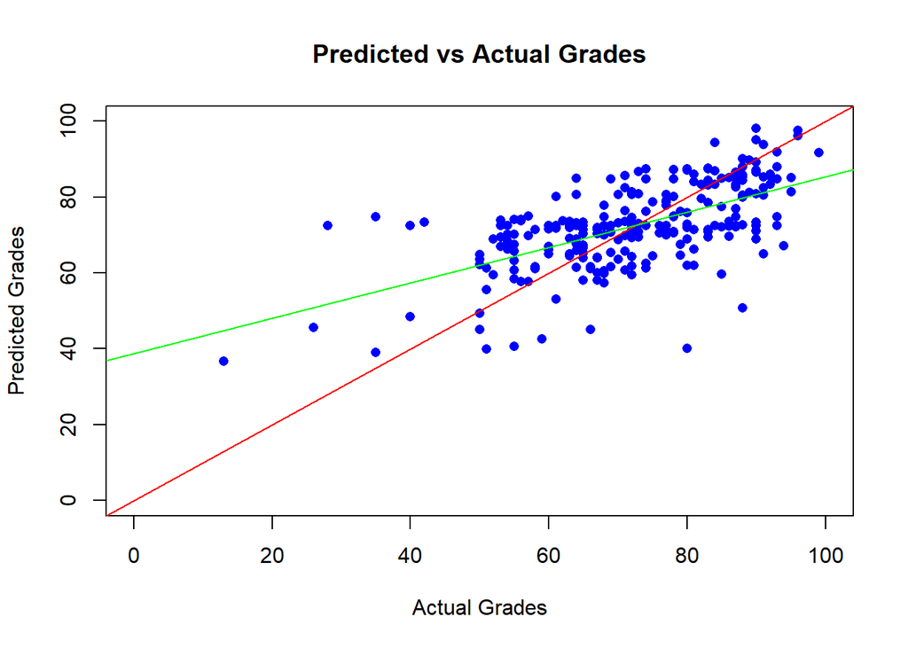

### Random Forest

In this section I’ve added the other ways I implemented random forests since many attempts were included above since missForest was used in order to keep as many rows as possible.

In this chunk I take the complete cases of MATH.100.1, MATH.101.1, STAT.230.1, and DATA.101.1 to train a RF model and predict STAT 230 grades. Note that this is using studentgrades_rep.

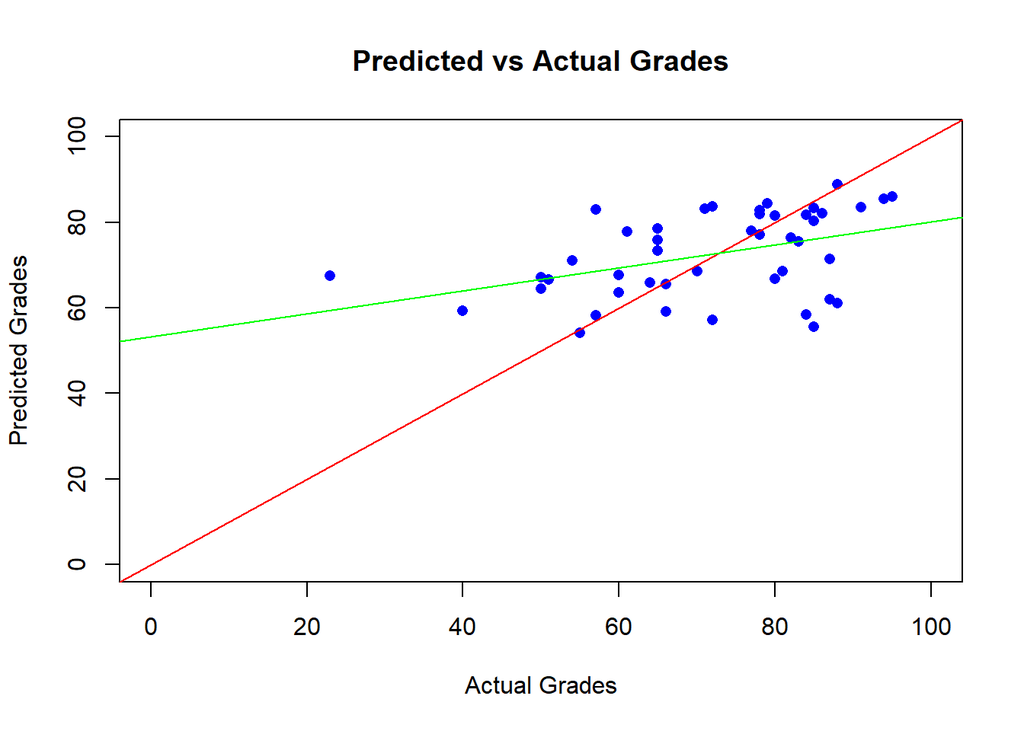

This chunk is a repeat of the previous one, except using studentgrades. Neither seem to produce decent predictions, however, I believe there is not enough data to make a good model.

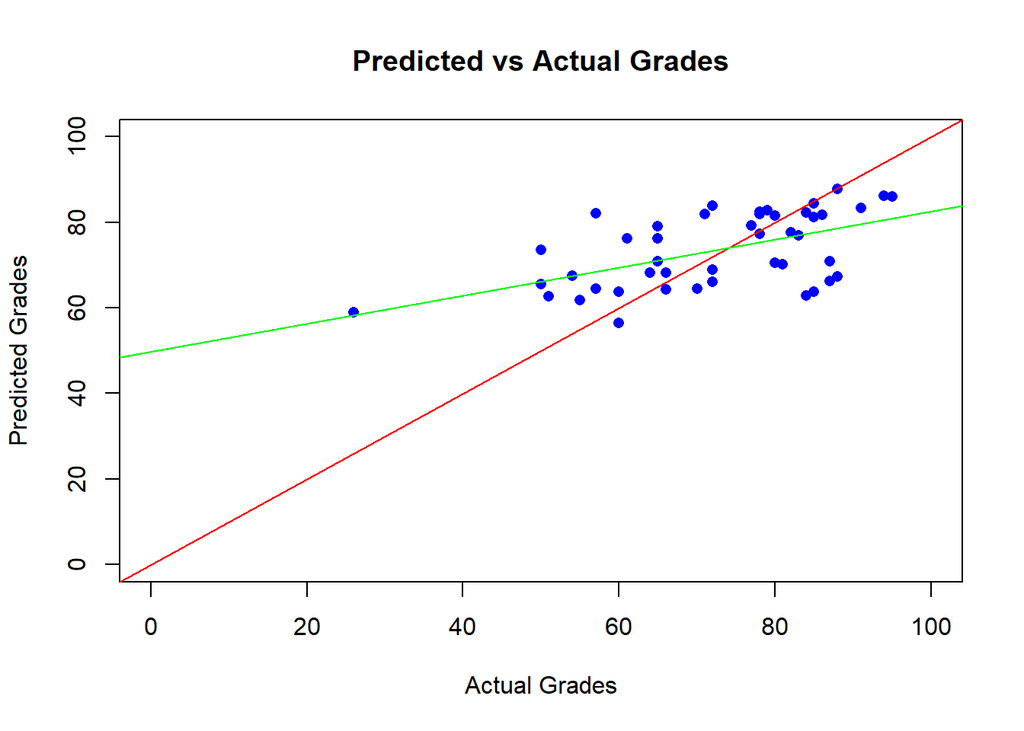

This chunk implements missForest and Random Forests to predict grades. However, only courses which have been taken a certain number of times (times_taken = 190) are used as predictors during imputation, training, and testing. This is a rudimentary variable selection method but ensures we use predictors with the most existing data. Leaks data unfortunately.

This is a repeat of the last chunk with modifications which make it easier to use different courses as the course we predict for.

### Gradient Boosted Machines

This section shows my initial attempts at gradient boosted machines. The first chunk uses studentgrades_rep to train and test on.

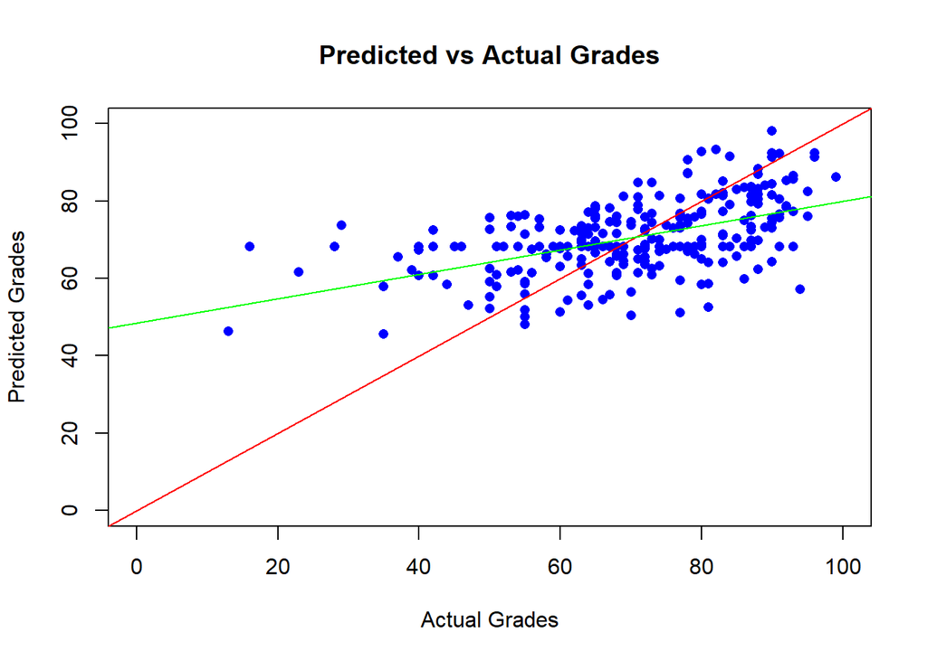

This chunk uses the complete cases of COSC.221.1, MATH.101.1, STAT.230.1, and DATA.101.1 from studentgrades_rep to train and test.

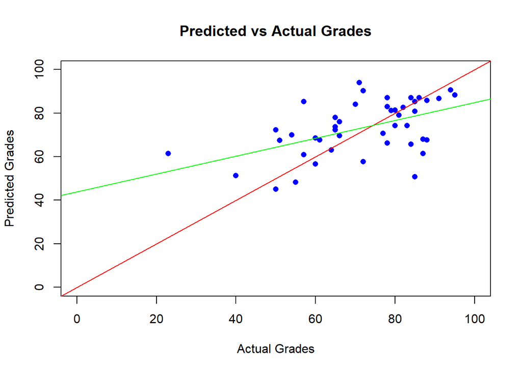

To cover all bases and check if it may be better, we impute grades onto the same courses and train a gbm model. The results are not great but quite a bit better than before.

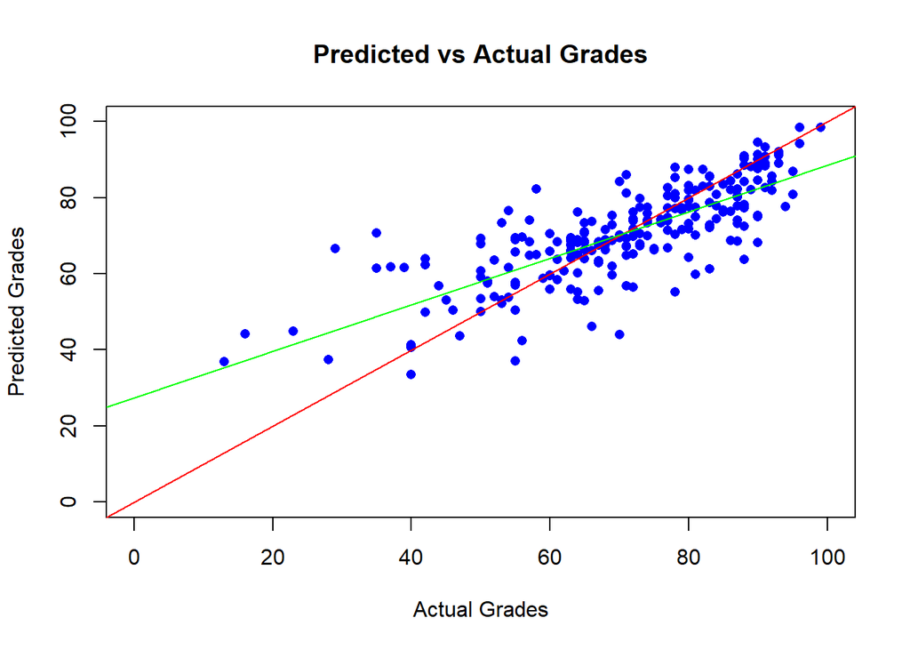

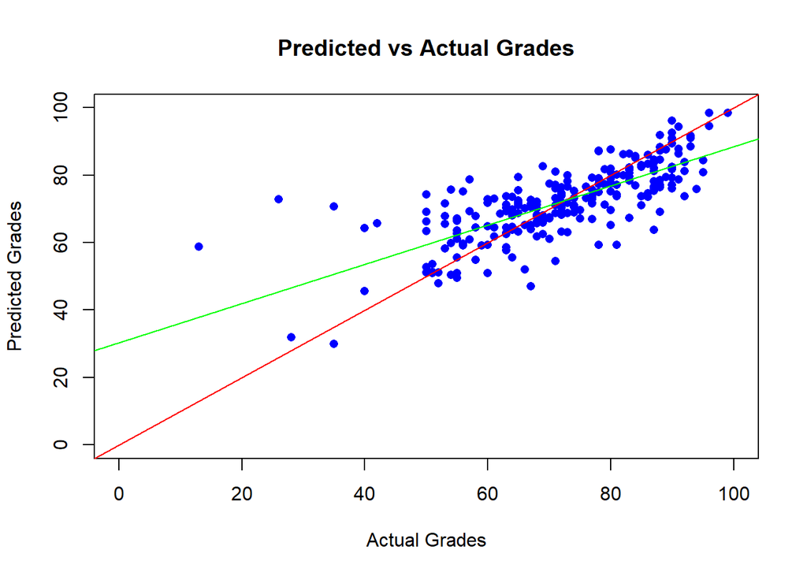

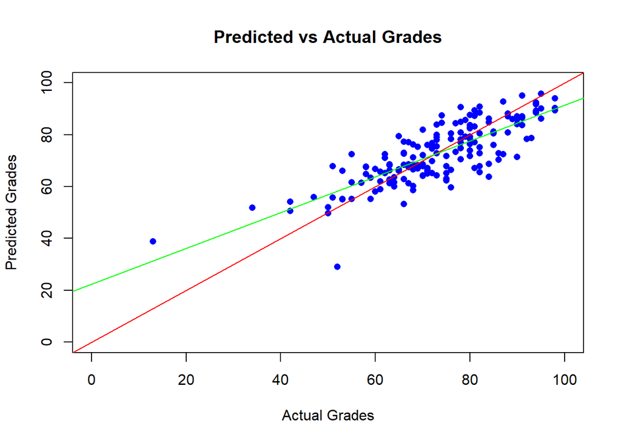

This chunk will use students grades of the current year (eg. second year uses STAT.230 and COSC.221) to train the GBM model. However, the test set will have grades from the current year removed (eg. won’t use COSC.221 as a predictor). In hindsight this isn’t a great idea when using GBMs as the decision trees used won’t be configured for the subset of courses used. Also to note, this uses studentgrades_rep.

### Matrix Factorization

Since the studentgrades data frame is highly dimensional I wanted to see if matrix factorization would work well on this dataset. The results were decent, and no grid search was implemented to further improve this method.

```
## iter      tr_rmse          obj
##    0      34.8863   3.4739e+07
##    1      14.1966   6.7044e+06
##    2      11.3044   4.6739e+06
##    3      10.3393   4.0972e+06
##    4       9.8965   3.8487e+06
##    5       9.6500   3.7114e+06
##    6       9.4944   3.6272e+06
##    7       9.3767   3.5610e+06
##    8       9.2851   3.5113e+06
##    9       9.2067   3.4696e+06
##   10       9.1361   3.4325e+06
##   11       9.0721   3.3979e+06
##   12       9.0101   3.3647e+06
##   13       8.9550   3.3356e+06
##   14       8.9030   3.3093e+06
##   15       8.8516   3.2819e+06
##   16       8.8083   3.2599e+06
##   17       8.7657   3.2394e+06
##   18       8.7256   3.2175e+06
##   19       8.6924   3.1995e+06
```

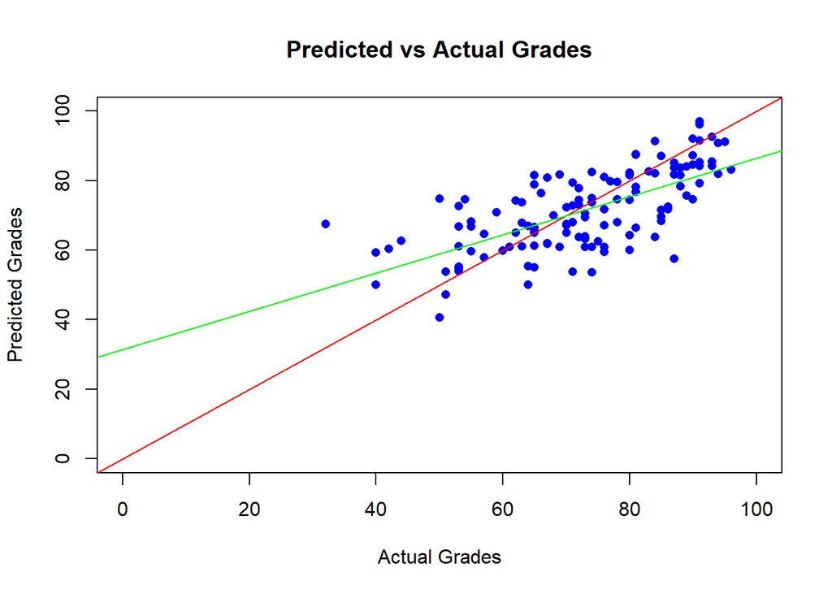

### Support Vector Machines

Many research papers online have said they get one of the best prediction from SVMs so I figured I had to try it out. Using the base package e1071 support vector machines were implemented, however the predictions were not as good as we imagined.

We figured that with traincontrol and some hyperparameter tuning we would get some better results. Fortunately we did get good results, including an rmse on par with GBMs. This was not initially tried with the professor data and may be worth revisiting.

```
## Support Vector Machines with Radial Basis Function Kernel
##
## 1027 samples
##   10 predictor
##
## No pre-processing
## Resampling: Cross-Validated (5 fold)
## Summary of sample sizes: 823, 821, 822, 822, 820
## Resampling results across tuning parameters:
##
##   sigma  C     RMSE       Rsquared   MAE
##   0.001    10   9.040714  0.6125264   6.815021
##   0.001   100   9.005889  0.6161737   6.761480
##   0.001  1000   8.959136  0.6215541   6.744972
##   0.010    10   8.911774  0.6241661   6.694496
##   0.010   100   9.114690  0.6100831   6.825200
##   0.010  1000   9.997329  0.5590792   7.106274
##   0.100    10   9.190550  0.6089964   6.762640
##   0.100   100  10.981310  0.5123051   7.903098
##   0.100  1000  17.747397  0.2973720  11.604325
##
## RMSE was used to select the optimal model using the smallest value.
## The final values used for the model were sigma = 0.01 and C = 10.
```

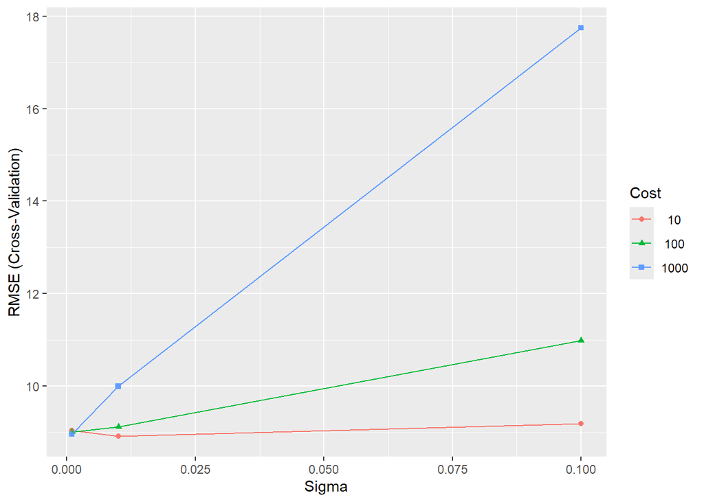

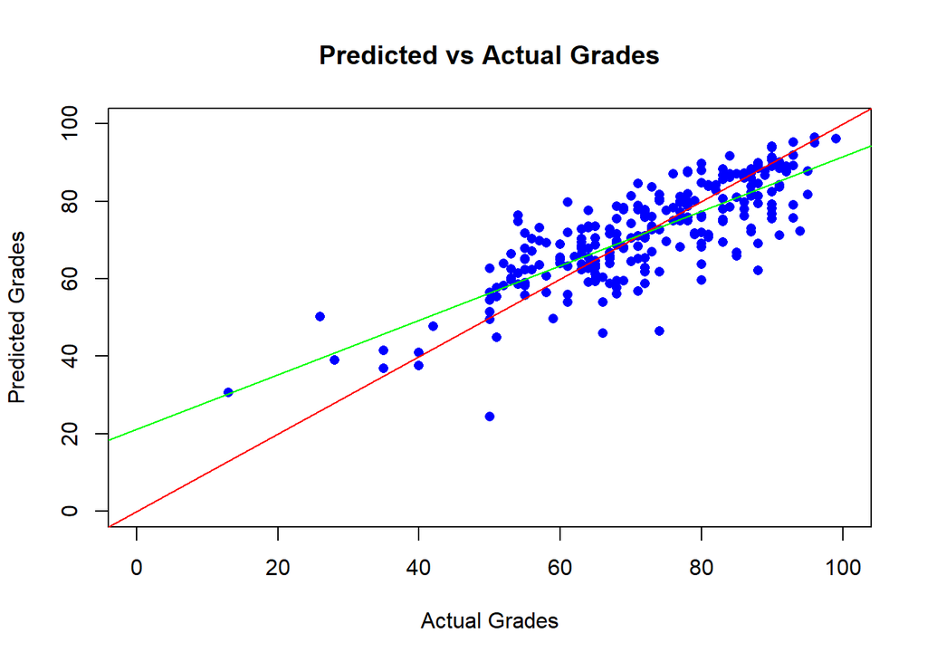

### Recursive Feature Elimination

This chunk was meant to be an attempt on using recursive feature elimination. However, this method doesn’t work for data with NA values and couldn’t be implemented with studentgrades.

### LASSO Feature Selection

In this section there are two incomplete chunks of code. I had moved off of working on feature selection as we deemed GBMs were doing a good job at indicating which courses are the most important. lasso regression doesn’t handle NA values so I tried to avoid that by using na.action = na.exclude. However, that didn’t work. Error: Every row has at least one missing value were found

### Singular Value Decomposition

I had moved away from trying different modeling methods to focus on improving GBMS.

## Further work on GBM

### Summary of the Boosting Process

1. **Initialize the model** with a constant value, typically the mean of the target values for regression:

$$F_0(x) = \arg\min_{c} \sum_{i=1}^{N} L(y_i, c)$$

2. **For $m = 1$ to $M$ (number of boosting iterations)**:
   - Compute the residuals $r_i^m$
   - For squared error loss, this simplifies to:
     $$r_i^m = y_i - F_{m-1}(x_i)$$
   - Fit a base learner $h_m(x)$ to the residuals.
   - Update the model via gradient decent:

$$F_{m}(x) = F_{m-1}(x) + \nu h_m(x)$$

3. **Final prediction** is the sum of all base learners:

$$\hat{y} = F_M(x) = \sum_{m=1}^{M} \nu h_m(x)$$

### Data Preperation

To prepare the data fror gradient boosting, I did some cleaning to ensure the data used for training and testing would be available at the time of prediction for the student. For example, a student who wishes to predict their future STAT 230 grade wouldn’t typically have 3rd or 4th year courses already completed. And definately wouldn’t have grades for any courses with STAT 230 as a prereq. In this chunk we remove data which doesn’t add to the training process. Immediately this is student ID, a students’ 2nd major, and whether they’re in honors (this could be included but isn’t for now). After removing all students who don’t have the pre requeset courses, columns (courses) are dropped if they are make up of too many NA values. In our case we want at least 20% of the data to be non-NA. This number was made arbitrarily to reduce the number of courses trained on. The best level of NA values used would be different depending on the course being predicted on. After that, we removed all courses from higher year levels as we wouldn’t expect them to be taken.

This chunk is for initializing STAT 230 GBM code as this was the main course I was testing on. It prepares a data frame to be passed into the GBM model for training and testing. The first data frame used includes students’ grades (without the new rows added) and professor data.

|  | Major.1 | Minor | MATH.101 | PSYO.121 | ENGL.150 | CHEM.121 | CHEM.123 | ENGL.153 | COSC.111 | ECON.101 |
| --- | --- | --- | --- | --- | --- | --- | --- | --- | --- | --- |
| 4 | COSC | PSYC | 84 | 89 | 52 | NA | NA | NA | 77 | 76 |
| 15 | COSC | BIOL | 90 | 78 | NA | 69 | 70 | NA | 77 | NA |
| 26 | MATH | STAT | 61 | NA | NA | NA | NA | 61 | 77 | 80 |
| 60 | COSC | NA | 84 | NA | NA | NA | NA | 65 | 75 | 70 |
| 63 | COSC | NA | 76 | 93 | NA | NA | NA | NA | 90 | NA |

### Analysis

In this chunk we run the entire data set through a GBM which trains the data in its entirety (there is 10-fold cross validation). From there we can find the performance of the GBM using both cross validation and OOB to display the optimal number of iterations. We determine that with a learning rate of 0.001 there is no need for any more than 8000 iterations.

The optimal number of iterations is used when training the model to ensure efficiency. CV folds is the only thing which hasn’t been strenuously tested to find the optimal number of folds. Additionally, we print out the model summary, use the model to predict grades, and calculate the rmse of the predicted grades.

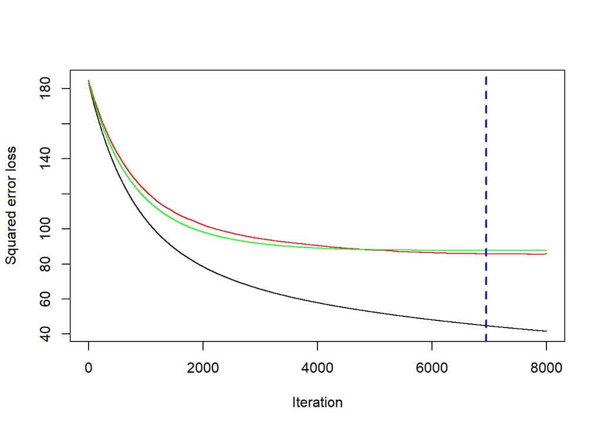

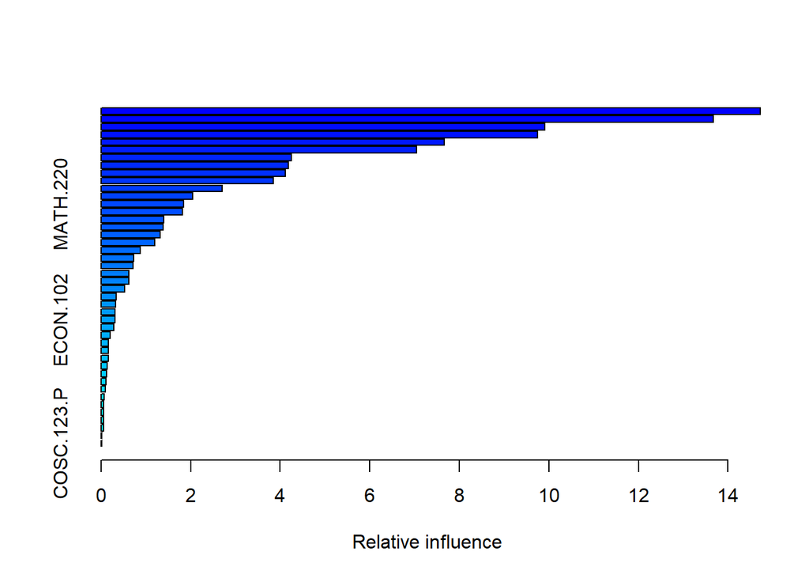

```
##                   var     rel.inf
## MATH.221     MATH.221 14.71970769
## COSC.211     COSC.211 13.67732433
## MATH.200     MATH.200  9.91443174
## COSC.221     COSC.221  9.74133027
## ENGL.112.P ENGL.112.P  7.66517787
## COSC.222     COSC.222  7.04839743
## ENGL.150.P ENGL.150.P  4.25143834
## COSC.121     COSC.121  4.18724906
## Major.1       Major.1  4.11632991
## DATA.101     DATA.101  3.84072497
## STAT.230.P STAT.230.P  2.70944763
## COSC.111     COSC.111  2.04036612
## MATH.220     MATH.220  1.83993216
## MATH.101.P MATH.101.P  1.82028810
## MATH.101     MATH.101  1.40374135
## PHYS.111     PHYS.111  1.39085920
## PSYO.121     PSYO.121  1.31767178
## ECON.101     ECON.101  1.19567164
## COSC.121.P COSC.121.P  0.86954768
## ENGL.150     ENGL.150  0.73409788
## MATH.221.P MATH.221.P  0.71455325
## COSC.111.P COSC.111.P  0.62367019
## CHEM.121     CHEM.121  0.62361852
## COSC.221.P COSC.221.P  0.52666455
## ENGL.153.P ENGL.153.P  0.34417089
## MATH.200.P MATH.200.P  0.31843834
## DATA.101.P DATA.101.P  0.31380144
## ECON.102     ECON.102  0.31080151
## CHEM.123     CHEM.123  0.27980179
## COSC.122     COSC.122  0.19748715
## COSC.101     COSC.101  0.16616560
## Minor           Minor  0.16379000
## PHYS.121     PHYS.121  0.15674142
## PSYO.111.P PSYO.111.P  0.13468552
## PHYS.111.P PHYS.111.P  0.12540418
## ECON.102.P ECON.102.P  0.10294690
## MATH.100.P MATH.100.P  0.08948819
## PHYS.121.P PHYS.121.P  0.06550102
## COSC.222.P COSC.222.P  0.06095838
## COSC.123     COSC.123  0.05916729
## ECON.101.P ECON.101.P  0.05910538
## ENGL.153     ENGL.153  0.05428506
## COSC.211.P COSC.211.P  0.01319948
## COSC.123.P COSC.123.P  0.01181882
```

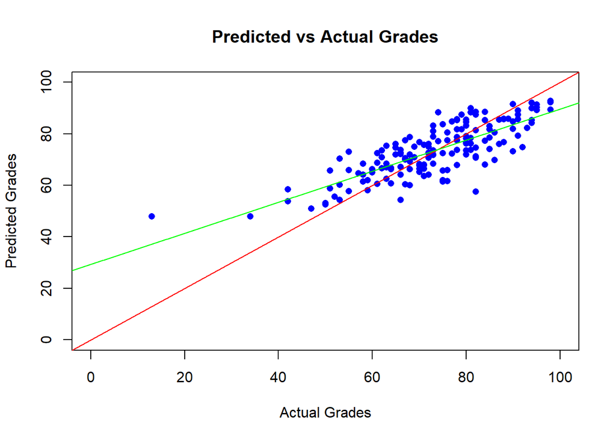

#### GBM Comparisons

The first one is a gradient boosted model performed on the new studentgrades data with professors included.

|  | Major.1 | Minor | Gender | Citizenship | Residency | PSYO.111 | ENGL.112 | MATH.100 | MATH.101 | PSYO.121 |
| --- | --- | --- | --- | --- | --- | --- | --- | --- | --- | --- |
| 4 | COSC | PSYC | NA | NA | NA | 72 | 54 | 65 | 84 | 89 |
| 15 | COSC | BIOL | NA | NA | NA | NA | NA | NA | 90 | 78 |
| 26 | MATH | STAT | M | Canada | DOMESTIC | 82 | 70 | 87 | 61 | NA |
| 61 | COSC | NA | NA | NA | NA | 79 | 60 | 70 | 84 | NA |
| 64 | COSC | NA | NA | NA | NA | 90 | NA | NA | 76 | 93 |

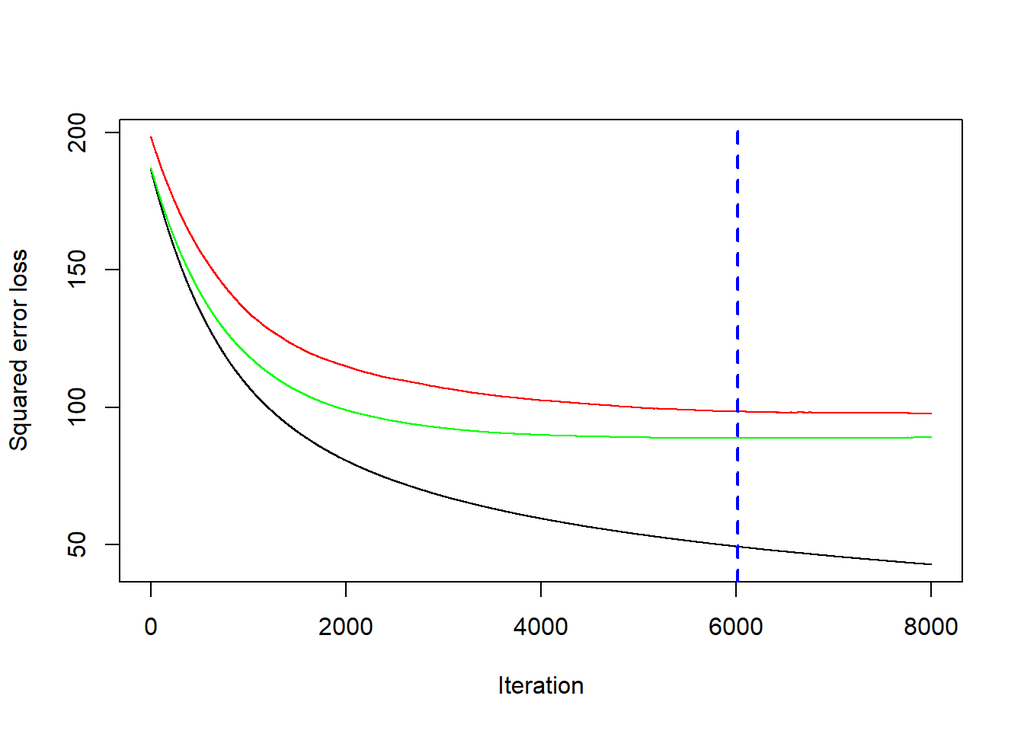

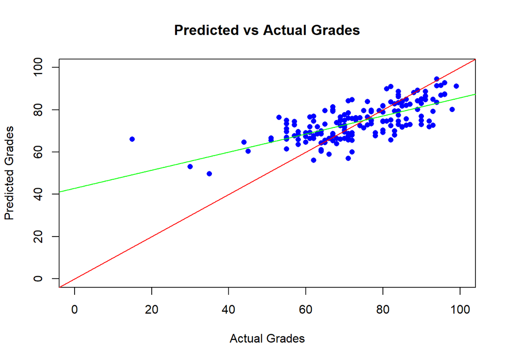

This GBM model uses both original and new students’ grades without the professor data.

|  | Major.1 | Minor | Gender | Citizenship | Residency | PSYO.111 | ENGL.112 | MATH.100 | MATH.101 | PSYO.121 |
| --- | --- | --- | --- | --- | --- | --- | --- | --- | --- | --- |
| 4 | COSC | PSYC | NA | NA | NA | 72 | 54 | 65 | 84 | 89 |
| 15 | COSC | BIOL | NA | NA | NA | NA | NA | NA | 90 | 78 |
| 26 | MATH | STAT | M | Canada | DOMESTIC | 82 | 70 | 87 | 61 | NA |
| 61 | COSC | NA | NA | NA | NA | 79 | 60 | 70 | 84 | NA |
| 64 | COSC | NA | NA | NA | NA | 90 | NA | NA | 76 | 93 |

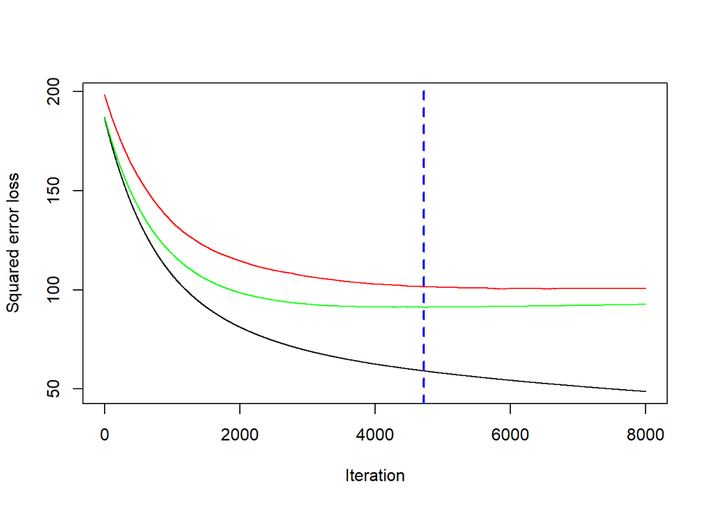

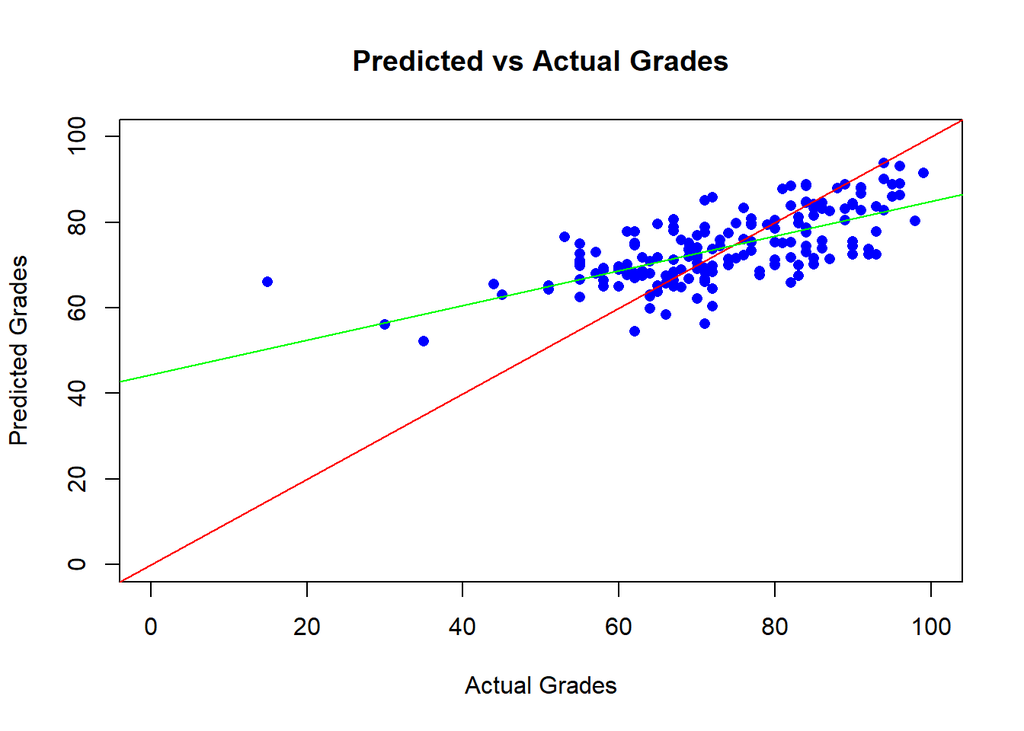

The final GBM model uses the original studentgrades data set with no professors.

|  | Major.1 | Minor | MATH.101 | PSYO.121 | ENGL.150 | CHEM.121 | CHEM.123 | ENGL.153 | COSC.111 | ECON.101 |
| --- | --- | --- | --- | --- | --- | --- | --- | --- | --- | --- |
| 4 | COSC | PSYC | 84 | 89 | 52 | NA | NA | NA | 77 | 76 |
| 15 | COSC | BIOL | 90 | 78 | NA | 69 | 70 | NA | 77 | NA |
| 26 | MATH | STAT | 61 | NA | NA | NA | NA | 61 | 77 | 80 |
| 60 | COSC | NA | 84 | NA | NA | NA | NA | 65 | 75 | 70 |
| 63 | COSC | NA | 76 | 93 | NA | NA | NA | NA | 90 | NA |

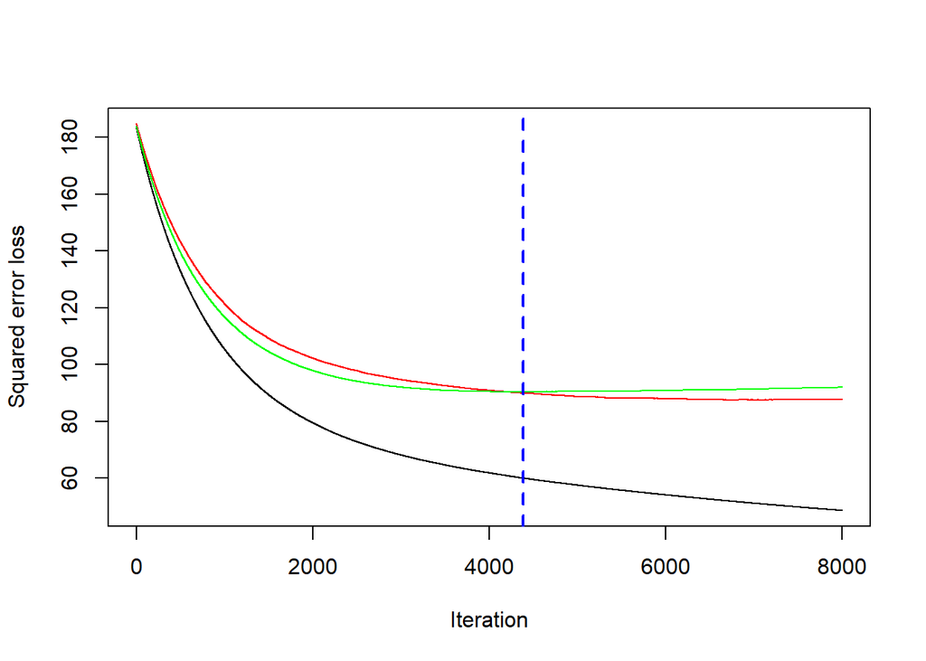

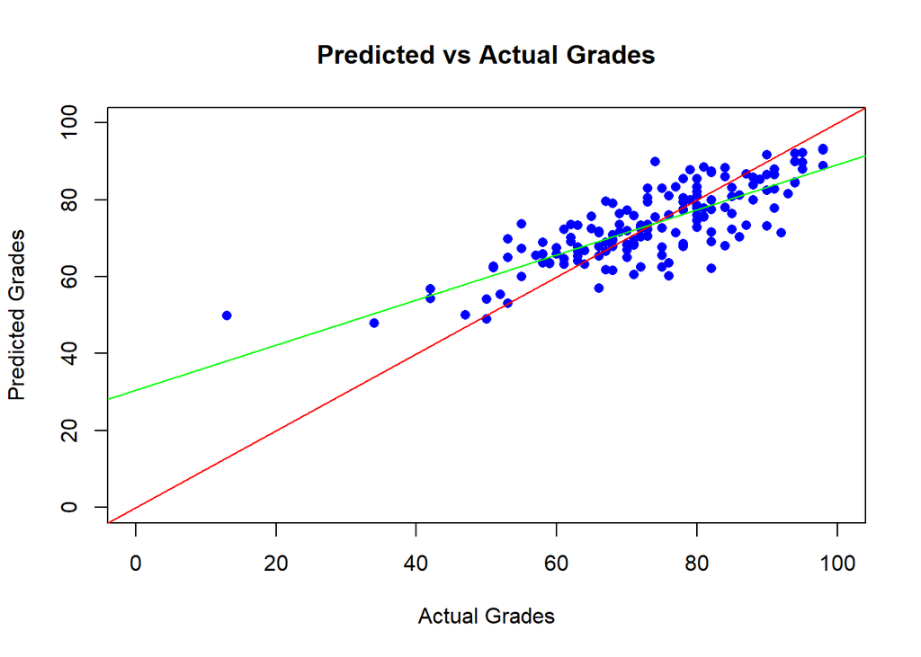

### Hyperparameter Training

Here we setup the GBM data for a few courses to find the best hyperparameters across many different courses.

Here we used trainControl to perform a grid search on the hyperparameters of the GBM algorithm. The main parameters are: n.trees - The number of iterations (decision trees built). interaction.depth - The maximum depth of decision trees. shrinkage - Learning rate (lower rate means it learns less per iteration), if this is too small the model is prone to overfitting. n.minobsinnode - minimum number of observations in terminal nodes. From this we found out a shrinkage of 0.001 or 0.01 is best, a interaction depth of 3-4 is best, the number of trees doesn’t matter as we find the optimal # anyways, and n.minobsinnode doesn’t have a large impact. Also, train.fraction and bag.fraction of 0.5 are best to ensure some randomness in the model.

### Adding Error Bars

This chunk adds error bars onto the graph of predicted vs actual grades. The error bars are calculated by taking the standard deviation of the absolute value of prediction grades - actual grades.

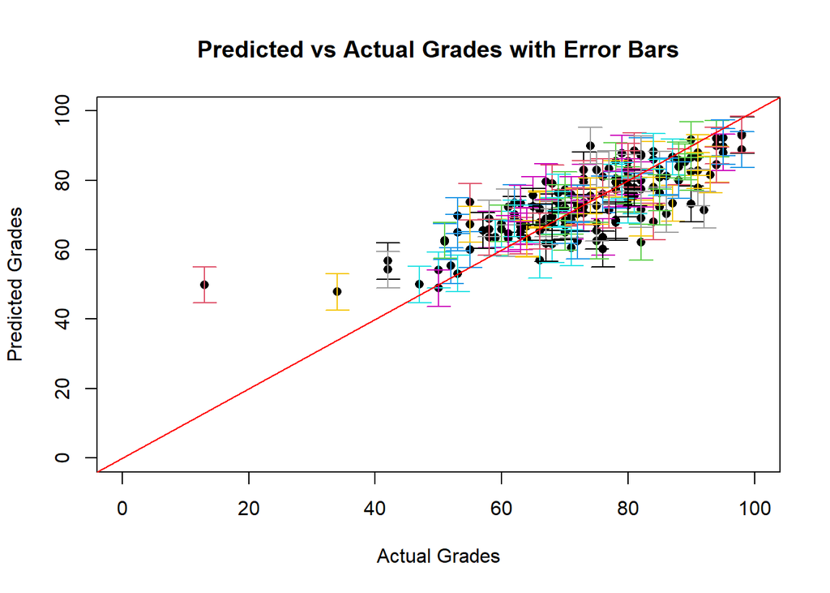

This chunk follows another paper in adding quantile error bars. These are calculated using the “quantile” distribution as a parameter to the gbm. Both upper and lower bounds on the quantile range are found a plotted alongside predictions.

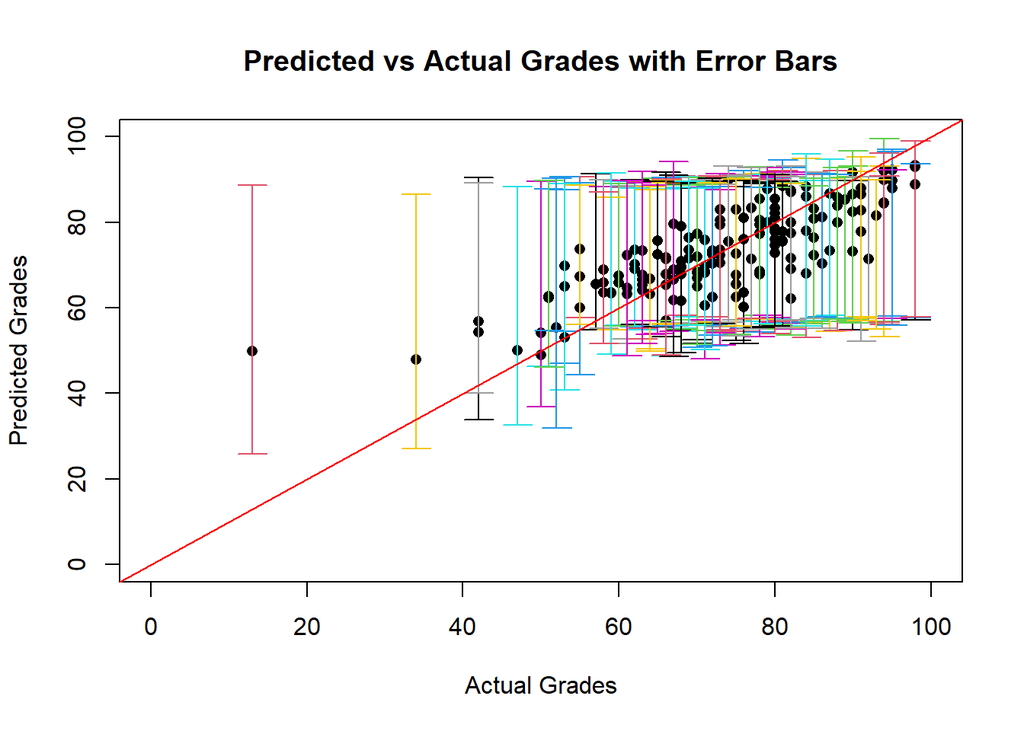

Our final way of calculating error bars is by bootstrapping the model 50 times and using the standard deviation to calculate the upper and lower bound for each grade predicted.

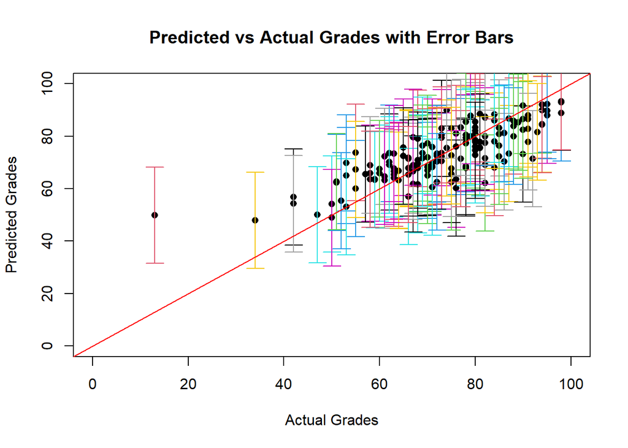

### Variable selection

This variable selection technique was taken from a **paper** with some modifications to see if removing variables improves the model. After training the model on all predictors, the two given the least importance by the gbm algorithm are removed and the model is trained again until either 2 or 1 predictors remain. For the first few courses removed it performed alright, with a rmse of ~9.5. However, as we can see the rmse never got any better and slowly increased to 10.8.

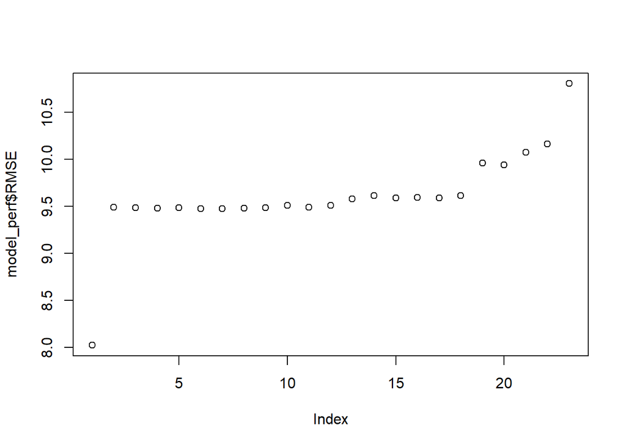

The output has been altered to show the RMSE of the model after two courses are consecutively removed from training/testing process.

## Extreme Gradient Boosting

Both Gradient Boosting Machines and Extreme Gradient Boosting follow the sample principle of gradient boosting. However, xgboost was designed to use a more regularized model formalization to control over-fitting. While this gives it better performance, I had more luck coding GBMS. For xgboost the hyperparameter training had to be set up very differently and with new parameters such as lambda and alpha training took considerably longer. Additionally, GBMs were found to be easier to set up each time allowing for the course we predict on to be changed easily.

This is the hyperparameter gridsearch for the xgboost algorithm. This is the chunk that showed that a subsample and colsample_bytree of 0.5 were best (bag.fraction and train.fraction from gbm hyperparameters).

The only error bars which could be implemented are the bootstrapped model since xgboost doesn’t support establishing the distribution of the boosting process like gbm.

## Main Plots Used

### Predicted grades vs Actual grades

The main plot we used to show progress was plotting the predicted student grades against their actual grades. This graph immediately shows us if we’re over or under predicting due to the red line. This line indicates “perfect prediction” as it follows where predicted grades = actual grades.

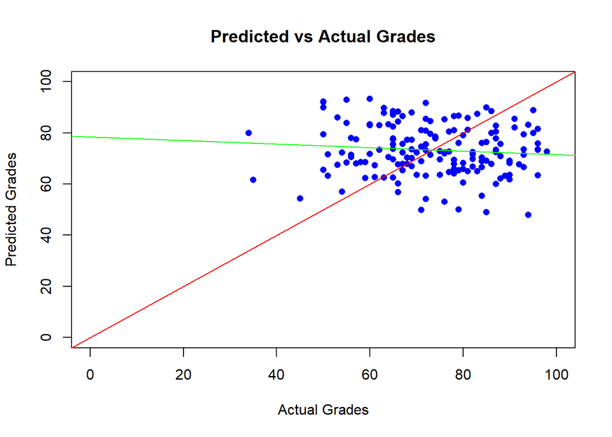

### Residuals

This was added in for model checking to make sure there are no trend in residuals.

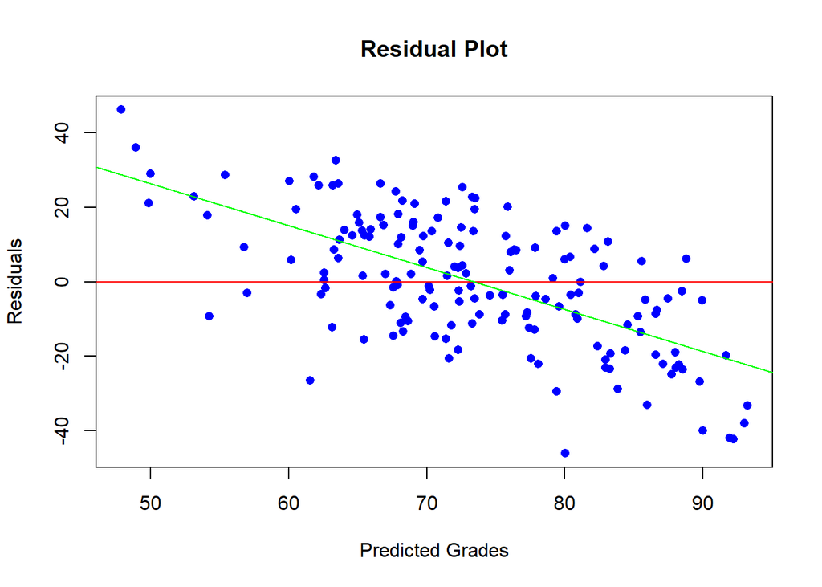

### Q-Q Plots

A q-q plot was also added in for model checking.

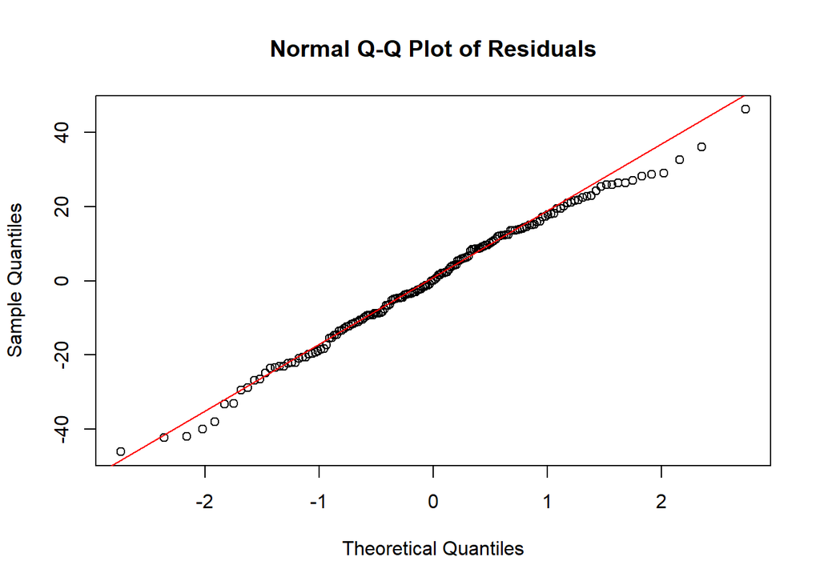

### Heatmap

The heatmaps were added to view the data more categorically. This first chunk splits predictions and actual grades into intervals of 5 (eg. 50-54, 55-59…) and produces a heatmap of predicted vs actual grades.

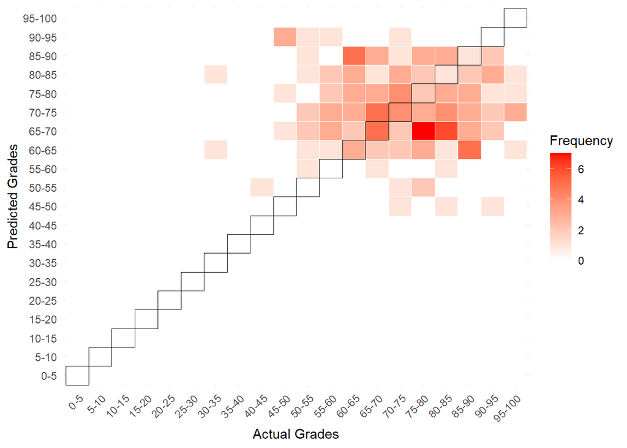

The second chunk splits predictions and actual grades into their letter grades and produces a heatmap of predicted vs actual grades using those splits.

```
## Confusion Matrix and Statistics
##
##           Reference
## Prediction F D C- C C+ B- B B+ A- A A+
##         F  0 0  0 0  0  0 0  0  0 1  1
##         D  0 0  0 0  0  1 0  2  0 0  0
##         C- 1 1  0 0  1  0 1  0  1 0  0
##         C  1 0  1 2  2  0 0  0  1 2  1
##         C+ 0 2  0 0  1  2 2  5  5 1  3
##         B- 0 1  5 1  4  4 1  2  4 3  3
##         B  0 2  1 2  2  3 3  3  3 2  5
##         B+ 0 0  2 0  4  2 3  1  1 4  1
##         A- 1 1  1 3  2  1 2  2  2 3  5
##         A  0 1  0 1  6  1 2  3  2 1  2
##         A+ 0 3  1 2  0  0 1  0  0 1  0
##
## Overall Statistics
##
##                Accuracy : 0.0859
##                  95% CI : (0.0478, 0.1399)
##     No Information Rate : 0.135
##     P-Value [Acc > NIR] : 0.9796
##
##                   Kappa : -0.0183
##
##  Mcnemar's Test P-Value : NA
##
## Statistics by Class:
##
##                      Class: F Class: D Class: C- Class: C Class: C+ Class: B-
## Sensitivity           0.00000  0.00000   0.00000  0.18182  0.045455   0.28571
## Specificity           0.98750  0.98026   0.96711  0.94737  0.858156   0.83893
## Pos Pred Value        0.00000  0.00000   0.00000  0.20000  0.047619   0.14286
## Neg Pred Value        0.98137  0.93125   0.93038  0.94118  0.852113   0.92593
## Prevalence            0.01840  0.06748   0.06748  0.06748  0.134969   0.08589
## Detection Rate        0.00000  0.00000   0.00000  0.01227  0.006135   0.02454
## Detection Prevalence  0.01227  0.01840   0.03067  0.06135  0.128834   0.17178
## Balanced Accuracy     0.49375  0.49013   0.48355  0.56459  0.451805   0.56232
##                      Class: B Class: B+ Class: A- Class: A Class: A+
## Sensitivity           0.20000  0.055556   0.10526 0.055556   0.00000
## Specificity           0.84459  0.882759   0.85417 0.875862   0.94366
## Pos Pred Value        0.11538  0.055556   0.08696 0.052632   0.00000
## Neg Pred Value        0.91241  0.882759   0.87857 0.881944   0.86452
## Prevalence            0.09202  0.110429   0.11656 0.110429   0.12883
## Detection Rate        0.01840  0.006135   0.01227 0.006135   0.00000
## Detection Prevalence  0.15951  0.110429   0.14110 0.116564   0.04908
## Balanced Accuracy     0.52230  0.469157   0.47971 0.465709   0.47183
```

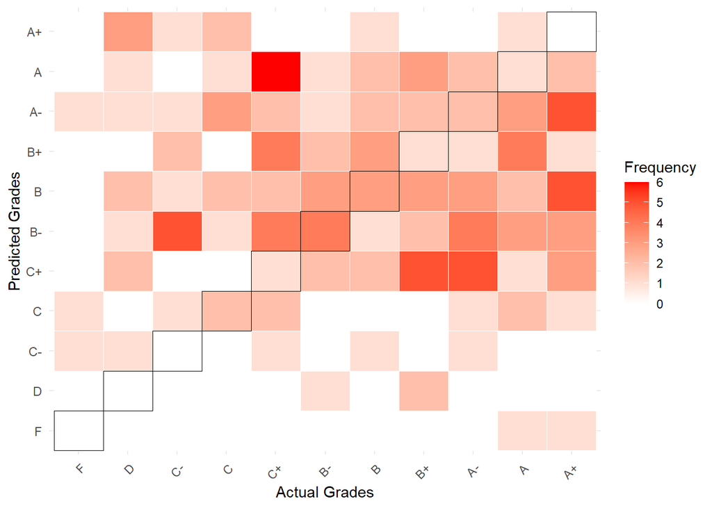

# Model Comparison

Here we plot the rmse of each model performed with a brief description. All models were trained to predict a student’s STAT 230 grade. The same train and test sets were used, with the exception of models using new student data.

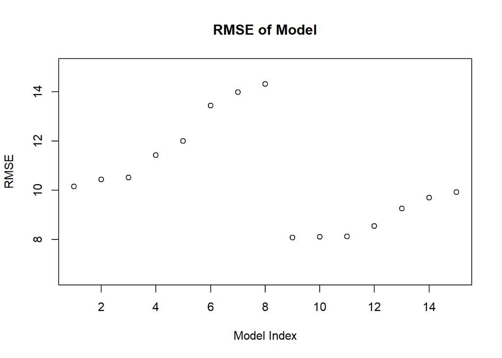

|  | RMSE | Model Details |
| --- | --- | --- |
| 14 | 10.1435171394858 | Gradient Boosted Machine (studentgrades_new) |
| 10 | 10.4401360555171 | Matrix Factorization on the 199 courses taken the most times (studentgrades) |
| 1 | 10.5134270936979 | Linear Regression on Prerequisites |
| 2 | 11.4157223231333 | MissForest imputation as prediction (studentgrades) |
| 4 | 12.0016918305814 | Random Forest on non-NA data (studentgrades) |
| 5 | 13.4252188719465 | Gradient Boosted Machines using 4 courses as predictors (studentgrades_rep) |
| 6 | 13.9704047400037 | Gradient Boosted Machines on complete cases of 4 courses (studentgrades_rep) |
| 3 | 14.3062058121751 | Random Forest on non-NA data (studentgrades_rep) |
| 9 | 8.06936950291683 | MissForest imputation into GBM on all courses (studentgrades) |
| 12 | 8.10779072419935 | Gradient Boosted Machine (studentgrades_prof) |
| 15 | 8.12934736025608 | Gradient Boosted Machine (studentgrades) |
| 11 | 8.53955307342219 | MissForest impute into Support Vector Machines (studentgrades) |
| 8 | 9.25509921867018 | MissForest imputation into GBM on 4 courses (studentgrades) |
| 7 | 9.6972834993597 | MissForest imputation into GBM on 4 courses (studentgrades_rep) |
| 13 | 9.91717155868055 | Gradient Boosted Machine (studentgrades_prof_new) |

Many of the earlier models proved to be ineffective for this problem containing mostly sparse data. There may be a way using neural networks to perform a time series analysis and prediction, but I didn’t have enough time to fully test it. Models including MissForest (except one) use the final test grades to impute the missing predictor grades, so predictions done using this form of imputation leak information and shouldn’t be used.

The best model I found was the gradient boosted machines which were able to handle spare data with ease. Most of the main analysis on these methods were done predicting STAT 230 as it had the most student grades to train/test on of all second year courses. For future improvements on GBMs, one could continue training hyperparameters on different courses or have a different setup for the training/testing data. Other than that I have pushed GBMs as much as they go. I wasn’t able to find any models which could handle sparse data as well, but I do think a well designed neural network has lots of potential. I never saved my results from NN predictions, but I averaged 9-11 rmse across the different model structures.